# Final Project - Bike Vendor

Rachel Steipp

4/28/2019

## Introduction

This is the final project for the Applied Data Science I590 course at Indiana University, Spring 2019.  
- The project’s objective is to discover insights through EDA by data cleaning, description, visualization, regression and cluster analysis of a dataset called BikeVendors.

### Questions: Initial

The following questions arise.

1. What is the distribution of the variable, price?
2. What is the relationship between price and the categorical variables?
3. Is there a relationship between the various bike vendors?
4. What is the relationship between price and geographic location of vendor?

## Data Description

On initial examination of the dataset, no missing data was found. The dimensions of this dataset are 97 rows by 35 columns. Each row or observation is one of 97 different models of bikes. Each observation has 35 variables, the first five include four character type variables model, frame, category1, category2, and one integer type variable, price.

The variables, model, frame, price are easily understood by their naming. Model of the bike is model. There are 97 in total with names like Bad Habit 1, SuperX Ultegra, and Jekyll Carbon 1. The material from which the frame is constructed, frame is either Aluminum or Carbon. The price, in dollars, of that bike model is a variable called price. The price range is from 415 on the low end to 12790 on the high end.

The next two variables, category1 and category2 are not readily known from their naming. They are rename in the cleaning of the data for clearer understanding of their contents. Describing the type of terrain the bike is suited for is the variable, category1. This variable changes to ‘terrain’ and can be either, Mountain or Road. Those can be further divided into terrain specialties. The variable, category2 changes to ‘specialty’. There are five specialties for mountian bikes; Cross Country Race, Fat Bike, Over Mountain, Trail, Sport and four specialties for road bikes; Cyclocross, Endurance Road, Elite Road, Triathalon.

The next 30 variables are bike vendors whose names represent a United States city and include Oklahoma City Race Equipment, Los Angeles Cycles, and Tampa 29ers. For each model of bike, the bike vendor has a decimal proportion based on how much inventory of that bike model the vendor has. There is a proportion for each of the 97 bike models. From this inspection, it is noticed that headers of vendor columns are values, not variable names. This issue is cleaned by making this wide data long using the ‘gather’ verb from the ‘dplyr’ package.

After describing and cleaning the data, the following two visualizations were looked at to see how the variables terrain, specialty, model, frame, and price fit together in a hierarchical structure to help with EDA question refinement.

### Initial Data Description Visuals

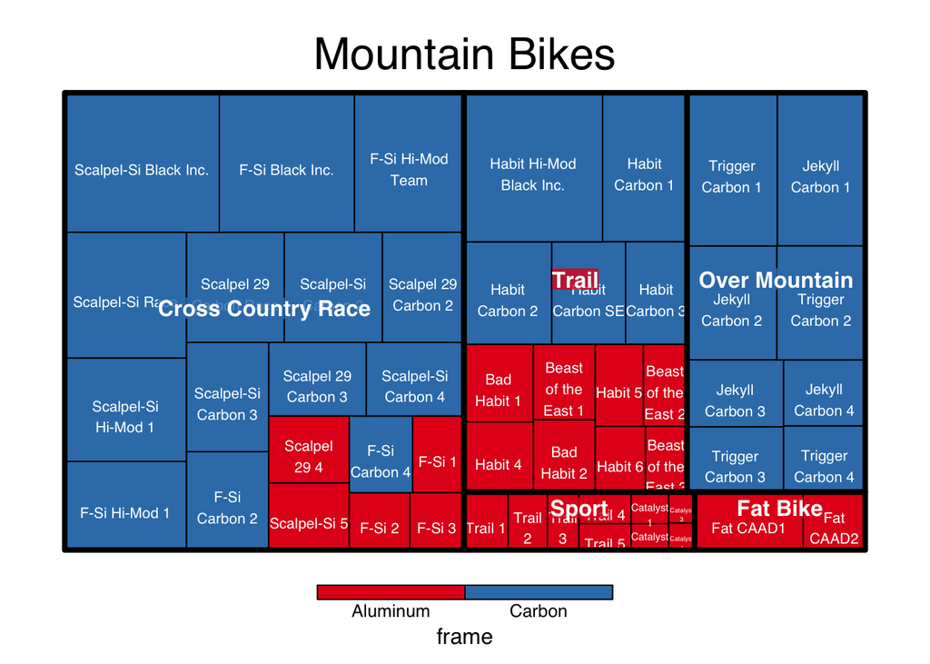

The visualization above takes an initial look at how the mountain bikes are hierarchically organized with specialty being the second level and then model, colored by frame compostion and the size of each model level rectangle is based on the price of that model of bike. It can be observed that all mountain bikes models with the specialty, Over Mountain have frames made of carbon and all Sport and Fat Bike have frames made of aluminum. The mountain bike with specialites, Cross Country Race and Trail have models with both carbon and aluminum frames.

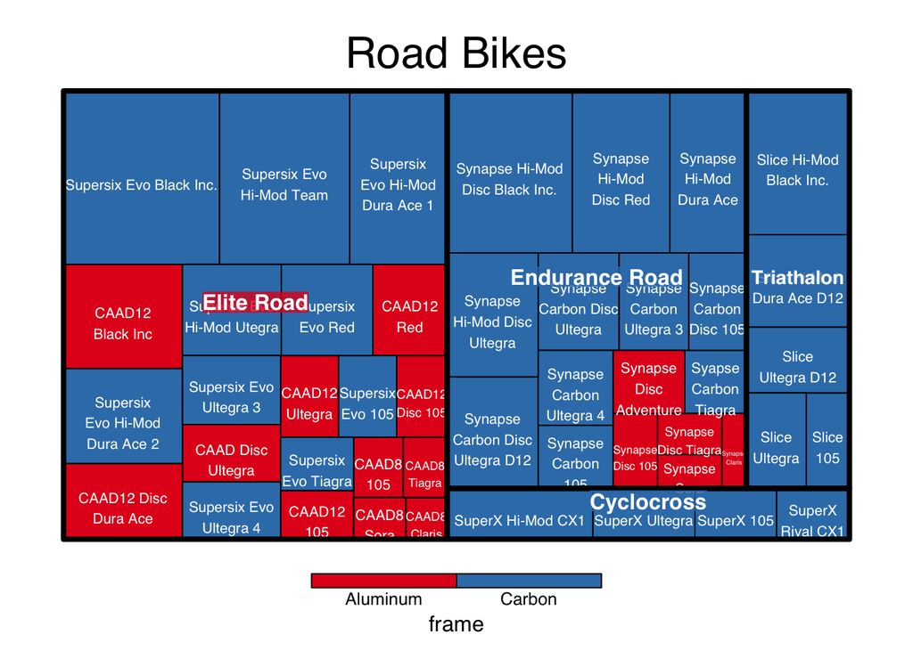

The visualization above takes an initial look at how the road bikes are hierarchically organized with specialty being the second level and then model, colored by frame compostion and the size of each model level rectangle is based on the price of that model of bike. It can be observed that all road bikes models with the specialty, Cyclocross and Triathalon have frames made of carbon. The road bike with specialites, Endurance Road and Elite Road have models with both carbon and aluminum frames.

## Questions: Redefined

1. What is the price distribution in terms of model and frame?
2. Which vendor(s), if any, carry the most variety of inventory by model?
   - How is that distributed?
3. Does geographic location determine inventories (mountain vs road)?
4. What is the relationship between price and the inventor percentage of the vendor, Phoenix Bi-peds?

## Data Exploration

The data exploration starts off with aggregating the data to include two more variables. This aggregation is based on the association of each vendor with a city in the United States. It will include two variables, Vendor_Latitude and Vendor_Longitude which correspond to the latitude and longitude of each city. Next is the examination of how the price of each bike model is distributed.

### Exploratory Plots

1. What is the price distribution in terms of model and frame?

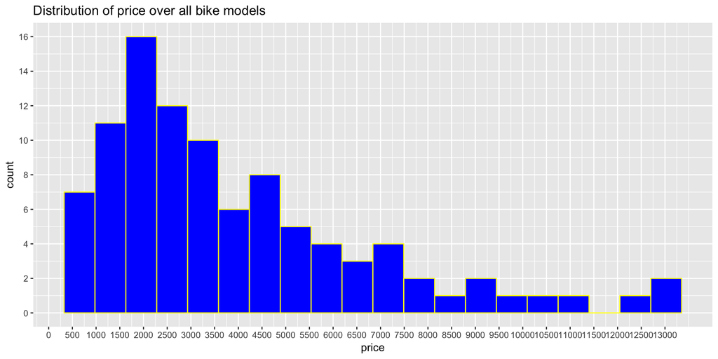

This visualization shows the distribution of price, in dollars, for all 97 varieties of bike models. There is a range of prices from 415 to 12790 with a mean of 3953 and a stanard deviation of 2871.89. As it shows in the graph the data is skewed to the right.

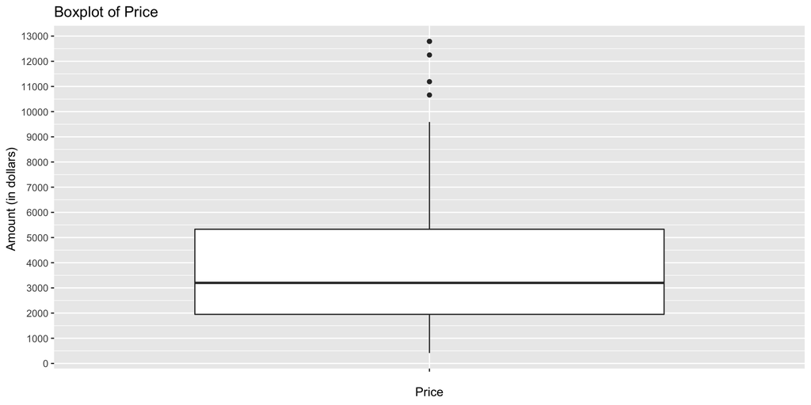

This visualation show another view of the same price data as the historgram above. From this plot the first and third quartlies are shown at 1950 and 5330 respectively. The five highest priced bike models, the ones above 10,000 dollars are outliers.

Although in the graph it looks like only four outliers are present. It is noted that the two highest priced bikes, Scalpel-Si Black Inc. and Supersix Evo Black Inc. are the same price, 12790. The other three outliers, Habit Hi-Mod Black Inc., F-Si Black Inc. and Supersix Evo Hi-Mod Team come in at 12250, 11190 and 10660 respectively. They are a mix of road and mountain bikes with various specialties, but their commonality is that all have frames made from carbon. Due to the highest price bikes all having carbon frames, the distribution of price for both types of frames, Aluminum and Carbon will be explored.

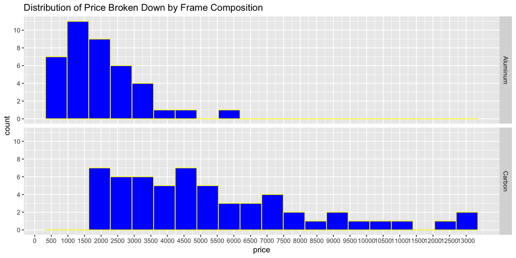

2. Which vendor(s), if any, carry all the varieties of inventory by model?
   - How is that distributed over the vendor?

From this, it is found that the number of vendors who carry all 97 variety of bike models is 3. They are Denver Bike Shop, Kansas City 29ers, and Phoenix Bi-peds.

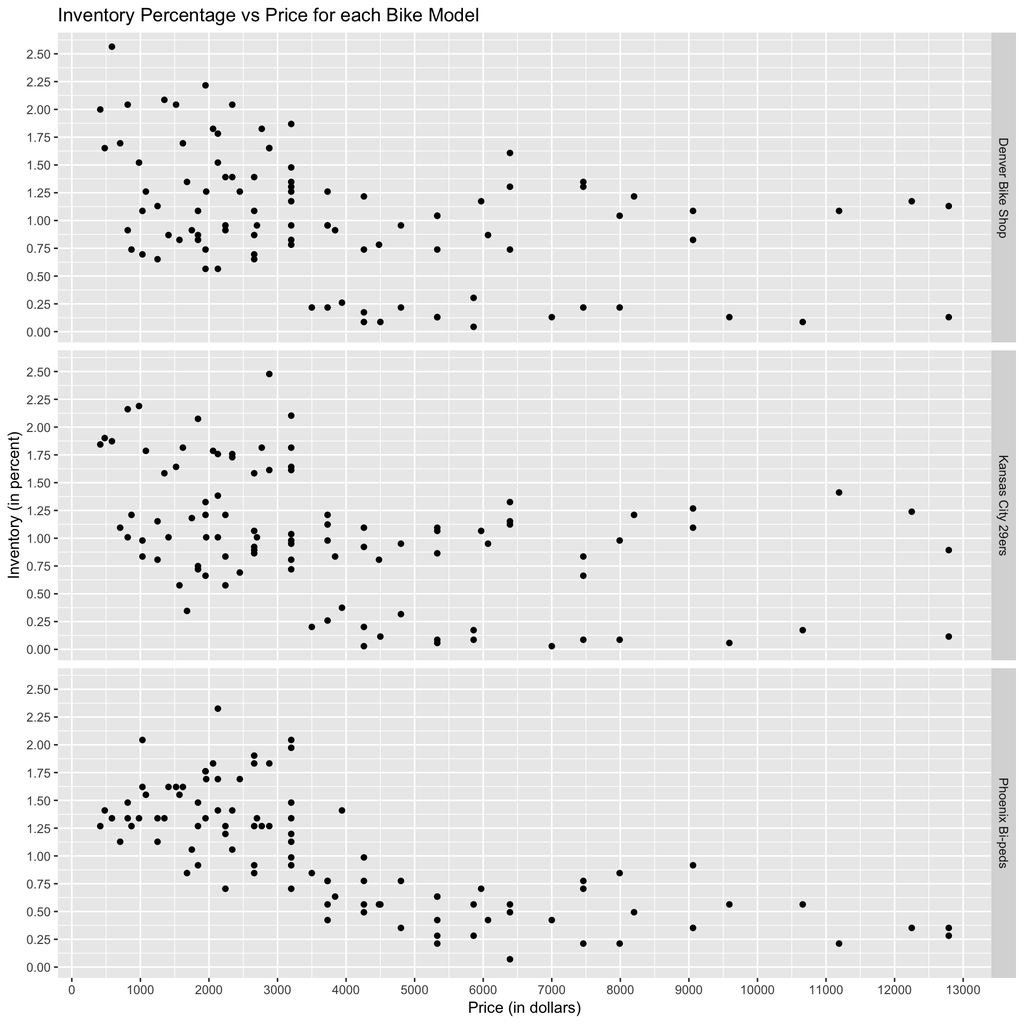

This visualization shows where each model of bike falls in terms of the percentage of inventory for the the three vendors that carry all 97 varieties of bike models, Denver Bike Shop, Kansas City 29ers, and Phoenix Bi-peds. It is shown that for the Denver Bike Shop all of it’s inventory that is above two percent is in the range of 0-2500 dollars. It is shown that for the Kansas City 29ers, unlike the Denver Bike Shop inventory that is above two percent is in the range of 0-5000 dollars. It is shown that for the Phoenix Bi-peds, unlike the Denver Bike Shop and the Kansas City 29ers the inventory percentage seems to gradually decrease then leveling out as the the price of the bikes increase.

### Cluster Anaylsis

3. Does geographic location determine inventories (mountain vs road)?

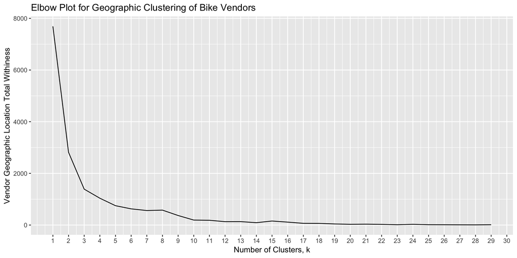

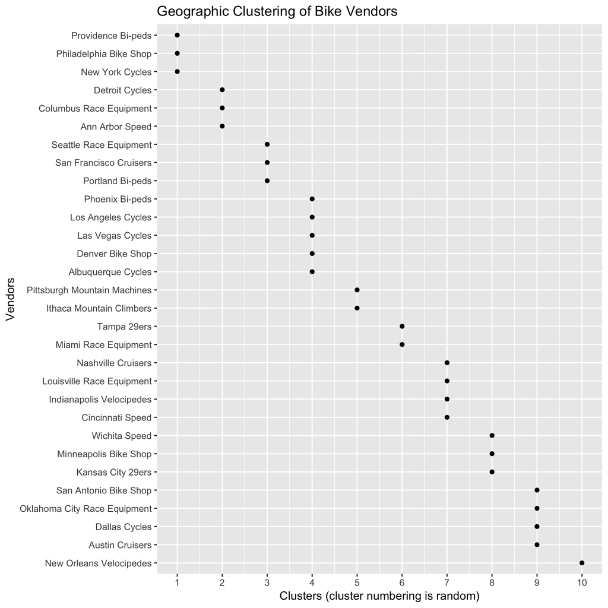

In the plot above and for anyone familiar with the geography of the United States these clusters seem fairly reasonable. There are ten clusters with groups ranging from one vendor to five vendors. The cluster number was randomly assigned to each of the clusters.

The thought for clustering this way being that vendors in similar geographic areas would most likely have similar terrain and there for would be interested in similar bikes. Cluster 1, which includes the Philadelphia Bike Shop, New York Cycles, and Providence Bi-peds will be examine to see if they have similar inventories regarding models of bikes that are either mountain or road bikes.

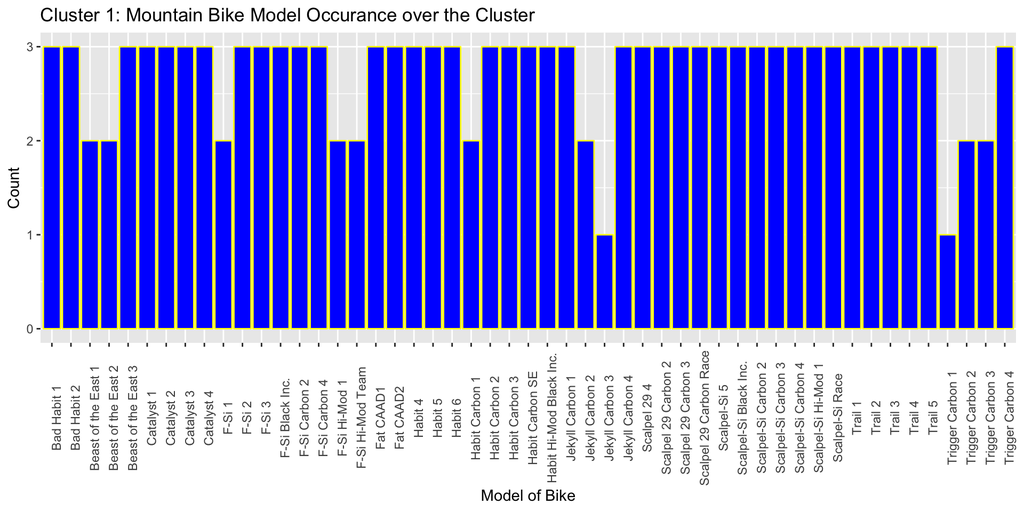

For the plot above, the count refers to how many of the three vendors in Cluster 1 have that particular model of mountain bike in their inventory. When considering similarity between the vendor’s inventory pay attention to the bike models with count three. All of the vendor’s inventory in Cluster 1 have 40 of the 51 mountain bike models in common.

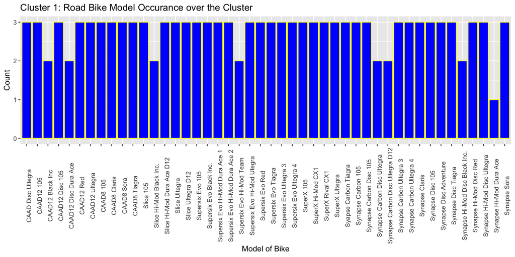

### Regression Analysis

4. What is the relationship between price and the inventor percentage of the vendor, Phoenix Bi-peds?

From the data exploration, it seems that for the Phoenix Bi-peds vendor there may be a negative linear association between the price of the bike models and the percentage of inventory that bike has. Take another look:

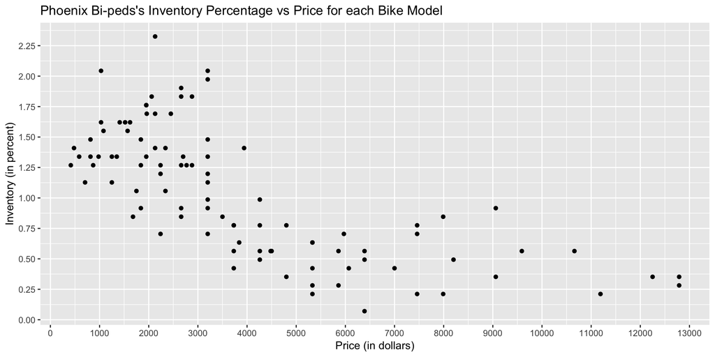

Here is the plot for the vendor Phoenix Bi-peds each point represent on of the 97 bike models. It seems to have a slightly negative linear relationship. A glm will be applied.

```
##
## Call:  glm(formula = Inv_Prcnt ~ price, family = "gaussian", data = Phoenix)
##
## Coefficients:
## (Intercept)        price
##   1.5383183   -0.0001283
##
## Degrees of Freedom: 96 Total (i.e. Null);  95 Residual
## Null Deviance:       26.67
## Residual Deviance: 13.63     AIC: 90.94
```

In this general linear model using the gaussian distribution the dependant variable is the ‘inventory percentage’ and the independant variable is the price. The function for the regression is as follows:

y = -0.0001283x + 1.5383183

Next a check for heteorgeneity in the residuals will be performed. If this model is a potential good fit for the data we expect the points to be randomly dispersed horizontally around zero.

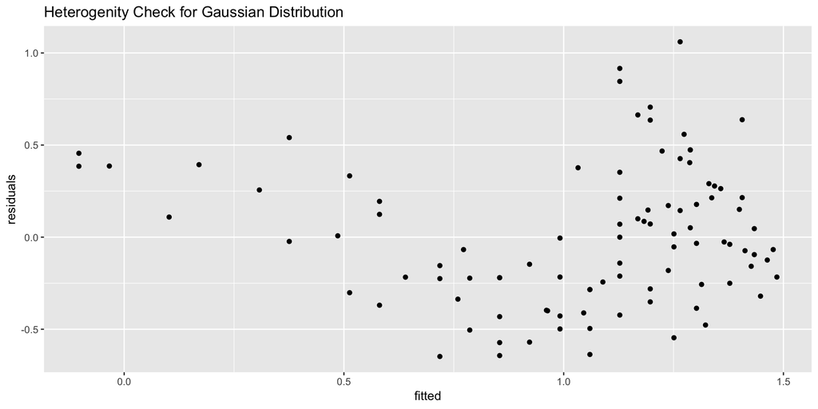

In the plot above the points are not randomly dispersed around zero and seem to spread as the fitted value increase. This means there is heterogenity. There for this general linear model is not a good fit for the data.

Now a poisson glm will be tried.

```
##
## Call:  glm(formula = Inv_Prcnt ~ price, family = "poisson", data = Phoenix)
##
## Coefficients:
## (Intercept)        price
##   0.5987616   -0.0001675
##
## Degrees of Freedom: 96 Total (i.e. Null);  95 Residual
## Null Deviance:       27.74
## Residual Deviance: 12.49     AIC: Inf
```

In this general linear model using the poisson distribution the same the dependant variable, ‘inventory percentage’ and independant variable, price are used. The function for the regression is as follows:

y = -0.0001675x + 0.5987616

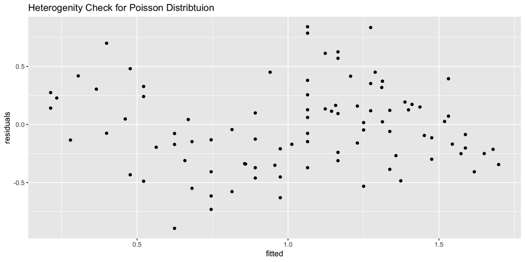

This heterogenity check plot when using the poisson distribution looks as though the points are more randomly distributed around zero than the one before.

Now a check for overdispersion will be done. This calculates the ratio between the residual deviance and the degrees of freedom.

```
##
##  Overdispersion test
##
## data:  PhoenixGLMP
## z = -23.268, p-value = 1
## alternative hypothesis: true dispersion is greater than 1
## sample estimates:
## dispersion
##  0.1191015
```

## Findings

1. What is the price distribution in terms of model and frame?

The distribution of price over the model of bikes is skewed to the right because of five found outliers which are all over 10000 dollars. When this is broken down to look at the two types of frames, carbon and aluminum, the carbon frame bikes are more uniformly distributed over a wider range of values than the aluminum bikes. Carbon framed bikes are also all of the five high price outliers. More exploration could be done to see if bike specialty or the type of terrain it was meant for had any factor when is comes to model price.

2. Which stores carry the most variety of inventory by model?

There are three vendors who have atleast one of every type of bike model in their inventory. When looking at the plots of inventory percentage versus price there does not seem to be a relationship between the three vendors inventories. Further investigation into how those bikes are distributed for those three vendors over terrain and specialty might add more insight into whether there is a relationship between the three.

3. Does geographic location determine inventories (mountain vs road)?

After the cluster analysis helped divid the vendors into geographically based cluster, an examination of Cluster 1 was performed. When looking at the model of bikes broken into road bike and mountain bikes, it was found that Cluster 1 has very similar inventories for both road and mountain bikes in terms of model type. The other cluster’s inventory distributions should be investigated to see whether geographic locations do determine inventories of vendors.